# Daphnia Report (Global Search)

# Settings

The 38-parameter Daphnia model is fitted from 50 matched starting points. IFAD uses 200 MPIF iterations followed by 200 Adam updates; MPIF alone uses 680 iterations. All searches use 1,000 particles per mesocosm and one Tesla V100 GPU, with two starts per batch.

The MPIF perturbation SD is 0.05 on the log scale, with a geometric cooling factor of 0.7 per 50 iterations. Adam uses a peak learning rate of 0.01, 10 warmup updates, and a cosine schedule with final multiplier 0.1. Likelihood evaluations use 2,000 particles per mesocosm and 10 independent particle filters. The best final parameter vector from each method is independently re-evaluated with the same particle count and number of replicates.

# Final log-likelihoods

The summary and plots include all 50 starts per method. MCSE is shown in parentheses.

| Method | Best log-likelihood (MCSE) | Median | Re-evaluated (MCSE) |
| --- | --- | --- | --- |
| IFAD-0.97 | -858.48 (0.17) | -861.42 | -858.23 (0.16) |
| IFAD-1 | -858.27 (0.17) | -861.46 | -858.00 (0.14) |
| IFAD-0 | -860.36 (0.24) | -864.12 | -860.30 (0.21) |
| MPIF | -860.06 (0.16) | -864.27 | -860.26 (0.14) |

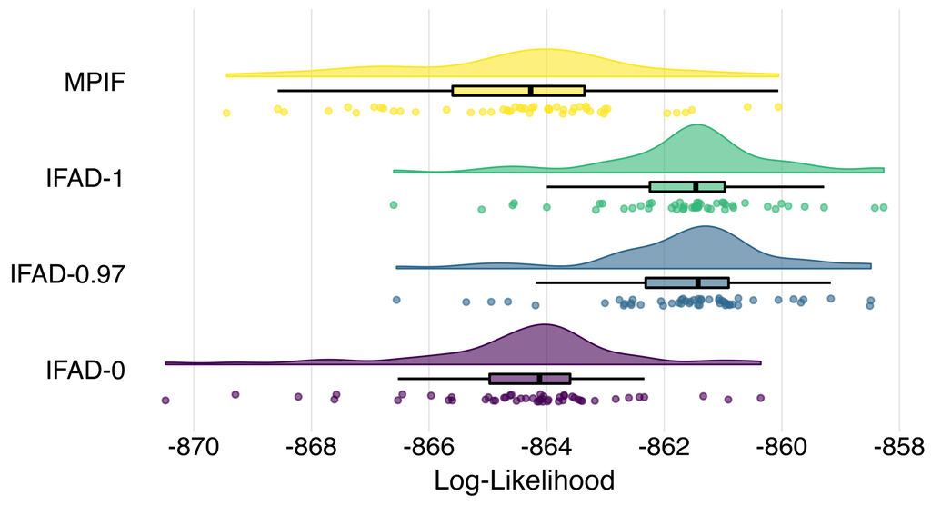

# Times

Times are summed over the 25 batches and include compilation. Optimization time excludes particle-filter evaluation. Checkpoint PF time covers the additional initial and intermediate evaluations.

| Method | MPIF (s) | DMOP (s) | Optimization (s) | Checkpoint PF (s) |
| --- | --- | --- | --- | --- |
| IFAD-0.97 | 534.9 | 1308.8 | 1843.6 | 281.5 |
| IFAD-1 | 519.9 | 1312.7 | 1832.6 | 270.3 |
| IFAD-0 | 502.6 | 1314.2 | 1816.8 | 259.9 |
| MPIF | 1591.0 | 0.0 | 1591.0 | 227.0 |

# Search progress

Lines show medians across 50 starts; ribbons span the 10th percentile to the maximum. Dotted vertical lines mark the switch from MPIF to Adam. Checkpoint times are mapped linearly within each phase using the summed batch runtimes. The plot shows log-likelihoods above −890.

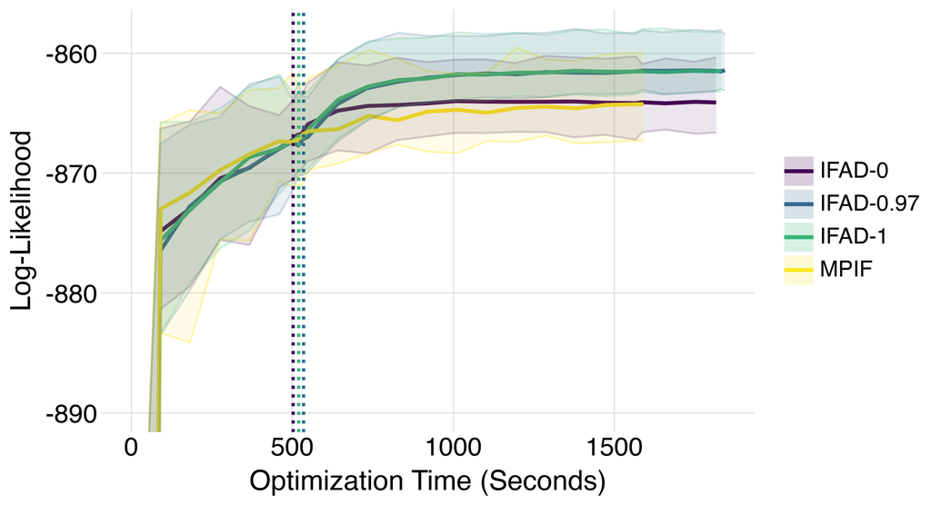